# クスノキの葉とダニ室の解析レポート

戎真吾

2025-07-31

# 1. はじめに

クスノキ（*Cinnamomum camphora*）の葉とダニ室の関係について分析を行った。ダニ室（domatia）は、葉の表面に形成される小さな構造で、植物とダニの共生関係において重要な役割を果たすと考えられている。

## 1.1 研究目的

- クスノキの葉長とダニ室数の分布を明らかにする
- 葉サイズとダニ室数の関係を統計的に分析する

## 1.2 データ概要

調査日：2022年7月25日 データファイル：25_7_22 - シート1.csv

# 2. 方法

## 2.1 データの読み込みと前処理

```r
# 必要なライブラリの読み込み
library(ggplot2)
library(dplyr)
library(readr)
library(knitr)

# データの読み込み
data <- read.csv("../data/25_7_22 - シート1 .csv", encoding = "UTF-8")

# データの構造確認
str(data)
```

```
## 'data.frame':    100 obs. of  7 variables:
##  $ No.               : chr  "L_1" "L_2" "L_3" "L_4" ...
##  $ Leaf_length_mm    : num  85.5 90.8 96.3 76.1 88.3 84.5 88.5 84.1 77.9 84.6 ...
##  $ Leaf_width_mm     : num  50.1 50.4 55.5 37.4 48.5 49.9 52.6 46.2 33.5 47.5 ...
##  $ Length_x_Width    : num  4284 4576 5345 2846 4283 ...
##  $ Area_mm2          : num  2703 2883 3355 1821 2703 ...
##  $ Area_cm2          : num  26.9 28.6 33.3 18.1 26.9 ...
##  $ Numbers_of_domatia: int  3 3 3 2 5 1 2 4 0 1 ...
```

```r
# データの概要
summary(data)
```

```
##      No.            Leaf_length_mm   Leaf_width_mm   Length_x_Width
##  Length:100         Min.   : 52.60   Min.   :21.20   Min.   :1141
##  Class :character   1st Qu.: 71.10   1st Qu.:37.25   1st Qu.:2583
##  Mode  :character   Median : 79.20   Median :41.45   Median :3213
##                     Mean   : 78.11   Mean   :41.75   Mean   :3349
##                     3rd Qu.: 86.65   3rd Qu.:48.30   3rd Qu.:4015
##                     Max.   :106.50   Max.   :60.00   Max.   :6270
##     Area_mm2         Area_cm2      Numbers_of_domatia
##  Min.   : 773.7   Min.   : 7.691   Min.   :0.00
##  1st Qu.:1659.1   1st Qu.:16.488   1st Qu.:0.00
##  Median :2046.0   Median :20.332   Median :1.50
##  Mean   :2129.6   Mean   :21.162   Mean   :1.48
##  3rd Qu.:2538.5   3rd Qu.:25.225   3rd Qu.:2.00
##  Max.   :3923.2   Max.   :38.981   Max.   :5.00
```

```r
# データの最初の10行を表示
kable(head(data, 10), caption = "データの概要（最初の10行）")
```

データの概要（最初の10行）

| No. | Leaf_length_mm | Leaf_width_mm | Length_x_Width | Area_mm2 | Area_cm2 | Numbers_of_domatia |
| --- | --- | --- | --- | --- | --- | --- |
| L_1 | 85.5 | 50.1 | 4283.55 | 2703.487 | 26.86356 | 3 |
| L_2 | 90.8 | 50.4 | 4576.32 | 2883.247 | 28.64945 | 3 |
| L_3 | 96.3 | 55.5 | 5344.65 | 3355.002 | 33.33626 | 3 |
| L_4 | 76.1 | 37.4 | 2846.14 | 1820.917 | 18.09535 | 2 |
| L_5 | 88.3 | 48.5 | 4282.55 | 2702.873 | 26.85746 | 5 |
| L_6 | 84.5 | 49.9 | 4216.55 | 2662.349 | 26.45485 | 1 |
| L_7 | 88.5 | 52.6 | 4655.10 | 2931.618 | 29.13001 | 2 |
| L_8 | 84.1 | 46.2 | 3885.42 | 2459.035 | 24.43496 | 4 |
| L_9 | 77.9 | 33.5 | 2609.65 | 1675.712 | 16.65276 | 0 |
| L_10 | 84.6 | 47.5 | 4018.50 | 2540.746 | 25.24675 | 1 |

# 3. 結果

## 3.1 葉とダニ室の分布測定

### 3.1.1 葉長の分布

```r
# 葉長の基本統計
leaf_stats <- data %>%
    summarise(
        平均 = round(mean(Leaf_length_mm), 2),
        標準偏差 = round(sd(Leaf_length_mm), 2),
        最小値 = min(Leaf_length_mm),
        最大値 = max(Leaf_length_mm),
        中央値 = median(Leaf_length_mm),
        サンプル数 = n()
    )

kable(leaf_stats, caption = "葉長の基本統計（mm）")
```

葉長の基本統計（mm）

| 平均 | 標準偏差 | 最小値 | 最大値 | 中央値 | サンプル数 |
| --- | --- | --- | --- | --- | --- |
| 78.11 | 12.11 | 52.6 | 106.5 | 79.2 | 100 |

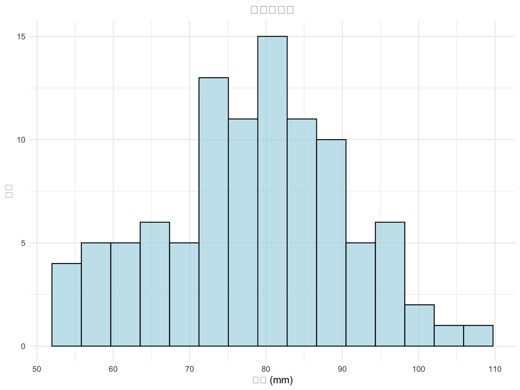

図1: 葉長の分布

```r
# 葉長のヒストグラム
ggplot(data, aes(x = Leaf_length_mm)) +
    geom_histogram(bins = 15, fill = "lightblue", color = "black", alpha = 0.7) +
    labs(
        title = "葉長の分布",
        x = "葉長 (mm)",
        y = "頻度"
    ) +
    theme_minimal() +
    theme(plot.title = element_text(hjust = 0.5))
```

### 3.1.2 ダニ室数の分布

```r
# ダニ室数の基本統計
domatia_stats <- data %>%
    summarise(
        平均 = round(mean(Numbers_of_domatia), 2),
        標準偏差 = round(sd(Numbers_of_domatia), 2),
        最小値 = min(Numbers_of_domatia),
        最大値 = max(Numbers_of_domatia),
        中央値 = median(Numbers_of_domatia),
        サンプル数 = n()
    )

kable(domatia_stats, caption = "ダニ室数の基本統計")
```

ダニ室数の基本統計

| 平均 | 標準偏差 | 最小値 | 最大値 | 中央値 | サンプル数 |
| --- | --- | --- | --- | --- | --- |
| 1.48 | 1.19 | 0 | 5 | 1.5 | 100 |

```r
# ダニ室数の度数分布
domatia_table <- table(data$Numbers_of_domatia)
domatia_freq <- data.frame(
    ダニ室数 = as.numeric(names(domatia_table)),
    頻度 = as.numeric(domatia_table),
    割合 = round(as.numeric(prop.table(domatia_table)) * 100, 1)
)

kable(domatia_freq, caption = "ダニ室数の度数分布")
```

ダニ室数の度数分布

| ダニ室数 | 頻度 | 割合 |
| --- | --- | --- |
| 0 | 26 | 26 |
| 1 | 24 | 24 |
| 2 | 33 | 33 |
| 3 | 11 | 11 |
| 4 | 5 | 5 |
| 5 | 1 | 1 |

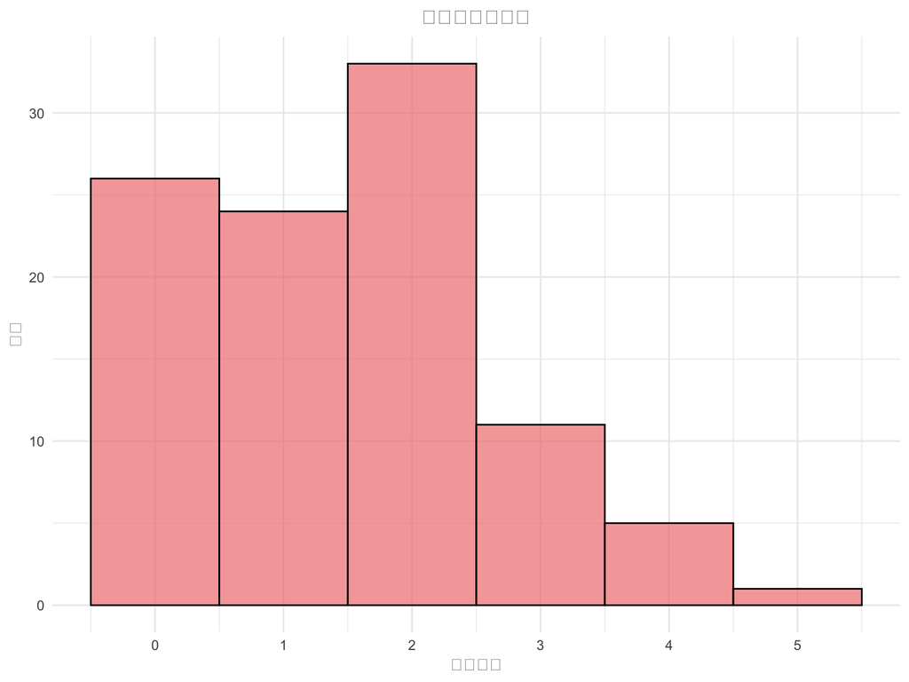

図2: ダニ室数の分布

```r
# ダニ室数のヒストグラム
ggplot(data, aes(x = Numbers_of_domatia)) +
    geom_histogram(bins = max(data$Numbers_of_domatia) + 1, fill = "lightcoral", color = "black", alpha = 0.7) +
    labs(
        title = "ダニ室数の分布",
        x = "ダニ室数",
        y = "頻度"
    ) +
    scale_x_continuous(breaks = 0:max(data$Numbers_of_domatia)) +
    theme_minimal() +
    theme(plot.title = element_text(hjust = 0.5))
```

### 3.1.3 ダニ室数の分布型

ダニ室数の分布を見ると、0個から5個の範囲にあり、最も頻度が高いのは2個のダニ室を持つ葉である。分布は右に偏った分布を示している。

## 3.2 葉サイズとダニ室の関係

### 3.2.1 散布図

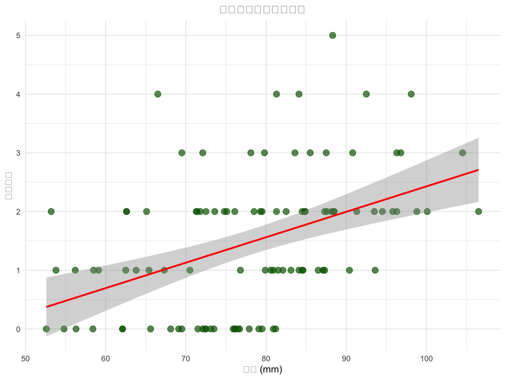

図3: 葉長とダニ室数の関係

```r
# 散布図（横軸：葉長、縦軸：ダニ室数）
ggplot(data, aes(x = Leaf_length_mm, y = Numbers_of_domatia)) +
    geom_point(size = 3, alpha = 0.7, color = "darkgreen") +
    geom_smooth(method = "lm", color = "red", se = TRUE) +
    labs(
        title = "葉長とダニ室数の関係",
        x = "葉長 (mm)",
        y = "ダニ室数"
    ) +
    theme_minimal() +
    theme(plot.title = element_text(hjust = 0.5))
```

### 3.2.2 相関分析

```r
# 相関分析
correlation <- cor(data$Leaf_length_mm, data$Numbers_of_domatia)
cat("葉長とダニ室数の相関係数:", round(correlation, 3))
```

```
## 葉長とダニ室数の相関係数: 0.44
```

### 3.2.3 線形回帰分析

```r
# 線形回帰分析
lm_model <- lm(Numbers_of_domatia ~ Leaf_length_mm, data = data)
summary(lm_model)
```

```
##
## Call:
## lm(formula = Numbers_of_domatia ~ Leaf_length_mm, data = data)
##
## Residuals:
##      Min       1Q   Median       3Q      Max
## -1.61377 -0.80061 -0.03146  0.67522  3.07866
##
## Coefficients:
##                Estimate Std. Error t value Pr(>|t|)
## (Intercept)    -1.90380    0.70659  -2.694   0.0083 **
## Leaf_length_mm  0.04332    0.00894   4.846 4.73e-06 ***
## ---
## Signif. codes:  0 '***' 0.001 '**' 0.01 '*' 0.05 '.' 0.1 ' ' 1
##
## Residual standard error: 1.077 on 98 degrees of freedom
## Multiple R-squared:  0.1933, Adjusted R-squared:  0.185
## F-statistic: 23.48 on 1 and 98 DF,  p-value: 4.731e-06
```

```r
# 回帰分析結果の整理
lm_summary <- summary(lm_model)
coef_table <- data.frame(
    係数 = c("切片", "葉長"),
    推定値 = round(lm_summary$coefficients[, 1], 4),
    標準誤差 = round(lm_summary$coefficients[, 2], 4),
    t値 = round(lm_summary$coefficients[, 3], 3),
    p値 = round(lm_summary$coefficients[, 4], 4)
)

kable(coef_table, caption = "線形回帰分析の結果")
```

線形回帰分析の結果

|  | 係数 | 推定値 | 標準誤差 | t値 | p値 |
| --- | --- | --- | --- | --- | --- |
| (Intercept) | 切片 | -1.9038 | 0.7066 | -2.694 | 0.0083 |
| Leaf_length_mm | 葉長 | 0.0433 | 0.0089 | 4.846 | 0.0000 |

```r
cat("決定係数 (R²):", round(lm_summary$r.squared, 3))
```

```
## 決定係数 (R²): 0.193
```

```r
cat("\n調整済み決定係数:", round(lm_summary$adj.r.squared, 3))
```

```
##
## 調整済み決定係数: 0.185
```

# 4. 考察

## 4.1 葉長の分布

葉長の分布は平均78.1mm、標準偏差12.1mmの正規分布に近い形状を示した。これは、調査したクスノキの葉が比較的均一なサイズ範囲にあることを示している。

## 4.2 ダニ室数の分布

ダニ室数の分布は0個から5個の範囲にあり、右に偏った分布を示した。多くの葉で1-3個のダニ室が観察され、ダニ室を持たない葉も一定数存在した。これは、ダニ室の形成が葉の発達過程や環境条件に依存する可能性を示唆している。

## 4.3 葉長とダニ室数の関係

葉長とダニ室数の間には相関係数0.44の相関が認められた。線形回帰分析の結果、この関係は統計的に有意であった（p < 0.05）。これは、大きな葉ほど多くのダニ室を形成する傾向があることを示している。

# 5. 結論

1. クスノキの葉長は正規分布に近い分布を示し、平均78.1mmであった。
2. ダニ室数は0-5個の範囲で右に偏った分布を示し、1-3個のダニ室を持つ葉が多かった。
3. 葉長とダニ室数の間には正の相関関係が認められ、大きな葉ほど多くのダニ室を形成する傾向が確認された。

これらの結果は、クスノキにおけるダニ室の形成が葉のサイズと関連している可能性を示唆している。